# COVID-19 Data Visualization & Exploration

Visualize the distribution of cases, the growth rate across countries and the behaviour in different states across India

# Data Source

World Data - Johns Hopkins University

World: https://data.humdata.org/dataset/novel-coronavirus-2019-ncov-cases

- time_series_covid19_confirmed_global_iso3_regions.csv
- time_series_covid19_deaths_global_iso3_regions.csv
- time_series_covid19_recovered_global_iso3_regions.csv

# Imports & Initialization

```python
import pandas as pd
import os
from functools import reduce
import operator
import numpy as np
import seaborn as sns
import matplotlib.pyplot as plt
import matplotlib.cm as cm
from matplotlib.colors import LogNorm
import copy
```

```python
base_input_dir = 'input/2Jan2020'
base_output_dir = 'output'
state_code_population_mapper_file = 'input/StateCodePopulationFile.csv'

world_confirmed_file = 'time_series_covid19_confirmed_global_iso3_regions.csv'
world_recovered_file = 'time_series_covid19_recovered_global_iso3_regions.csv'
world_death_file = 'time_series_covid19_deaths_global_iso3_regions.csv'

india_confirmed_file = 'confirmed.csv'
india_recovered_file = 'recovered.csv'
india_death_file = 'deceased.csv'
```

# Utility Functions

## Read input csv file

```python
# Ensure "NA" in data is not read as NaN by Python
# Function reads the first 25 lines of the file and identifies if a column is of type string or numeric
# NA values are replaced with NaN only for numeric columns
def conversion_na_values(abs_filename, nrows=25, sep=';', read_as='csv', na_values=None):
    if na_values is None:
        na_values = ["", ".", "-", "NA"]
    if read_as == 'csv':
        tmp_df = pd.read_csv(abs_filename, nrows=nrows, sep=sep, float_precision='round_trip', na_values=na_values)
    elif read_as == 'xls':
        tmp_df = pd.read_excel(abs_filename, nrows=nrows, na_values=na_values)

    na_values_cols = {}
    for col in tmp_df.columns:
        na_values_cols[col] = [''] if tmp_df[col].dtype == 'object' else na_values

    return na_values_cols

def read_data(filepath, sep=','):
    na_values_cols = conversion_na_values(filepath, sep=',')
    return pd.read_csv(filepath, sep=sep, index_col=False, na_values=na_values_cols,  float_precision='round_trip')
```

## Read the world data file to dataframes

Dataframes Returned:

- complete original data,
- total cases per country
- daily reported cases by date

```python
def parse_world_CRD_file(world_filename,file_prefix):

    world_total = read_data(os.path.join(base_input_dir,world_filename), sep=',')
    print(f'Parsing file:{world_filename}')
    print(f'Shape:{world_total.shape}')

    #Delete 1st row
    world_total = world_total[1:]

    # Roll-up on country-region
    drop_columns_for_country_rollup = ['Province/State','Lat','Long','ISO 3166-1 Alpha 3-Codes',
           'Region Code', 'Region Name', 'Sub-region Code', 'Sub-region Name',
           'Intermediate Region Code', 'Intermediate Region Name']
    world_byCountry = world_total.drop(drop_columns_for_country_rollup, axis=1)
    world_byCountry=world_byCountry.groupby(["Country/Region"],as_index=False).sum()

    # Transpose to get world_byDate
    world_byDate = world_byCountry.set_index('Country/Region').T
    world_byDate = world_byDate.reset_index().rename(columns={'index':'Date'})

    # Find total_ and daily_ for world_byDate
    world_byDate[f'Total_{file_prefix}'] = world_byDate.iloc[:,1:].sum(axis=1)
    world_byDate[f'Daily_{file_prefix}'] = world_byDate[f'Total_{file_prefix}'].diff(periods=1)

    # Find total_ for world_byCountry
    last_date_column_name = world_byCountry.columns[-1]
    world_byCountry[f'Total_{file_prefix}'] = world_byCountry.iloc[:,-1]


    # Find total_ for world_total
    world_total[f'Total_{file_prefix}'] = world_total[last_date_column_name]

    return world_total,world_byCountry,world_byDate
```

## Function to create a subset of a dataframe based on the given condition

```python
def subset_on_condition(input_df, parameters):
    condition = parameters.get("condition", '>=')
    operators = {'>': operator.gt,
                 '<': operator.lt,
                 '>=': operator.ge,
                 '<=': operator.le,
                 '=': operator.eq,
                 '!=': operator.ne}

    if condition not in operators:
        raise Exception(f'Condition operator not supported:{condition}')

    condition_op = operators[condition]
    final_df = pd.DataFrame()
    for column_name in input_df.columns:
        column_df = pd.DataFrame(input_df[column_name][condition_op(input_df[column_name], parameters["value"])])
        column_df.reset_index(drop=True, inplace=True)
        final_df = pd.concat([final_df, column_df], ignore_index=True, axis=1)

    final_df.columns = input_df.columns
    # Add index column if required
    if "index_column_name" in parameters:
        final_df.insert(loc=0, column=parameters["index_column_name"], value=np.arange(1, len(final_df) + 1))
    return final_df
```

# Read the data

## Parse the world input files and get the dataframes for the cases ordered by country and ordered by Date

```python
confirmed_total,confirmed_byCountry,confirmed_byDate = parse_world_CRD_file(world_filename=world_confirmed_file,file_prefix = 'confirmed')
recovered_total,recovered_byCountry,recovered_byDate = parse_world_CRD_file(world_filename=world_recovered_file,file_prefix = 'recovered')
death_total,death_byCountry,death_byDate = parse_world_CRD_file(world_filename=world_death_file,file_prefix = 'death')
```

```
Parsing file:time_series_covid19_confirmed_global_iso3_regions.csv
Shape:(272, 357)
Parsing file:time_series_covid19_recovered_global_iso3_regions.csv
Shape:(257, 357)
Parsing file:time_series_covid19_deaths_global_iso3_regions.csv
Shape:(272, 357)
```

# Data Preprocessing

## Create world_CRD_byDate by joining the data from confirmed, recovered & death dataframes

CRD - Confirmed, Recovered, Death/Deceased

```python
# Merge confirmed & recovered cases
world_CR_byDate =  pd.merge(confirmed_byDate[['Date','Total_confirmed','Daily_confirmed']],recovered_byDate[['Date','Total_recovered','Daily_recovered']],how='outer',on=['Date'])
# Merge result with death cases
world_CRD_byDate =  pd.merge(world_CR_byDate[['Date','Total_confirmed','Daily_confirmed','Total_recovered','Daily_recovered']],death_byDate[['Date','Total_death','Daily_death']],how='outer',on=['Date'])

# write_csv_output(df=world_CRD_byDate, filename='world_CRD_byDate')
```

## Create world_CRD_byCountry by joining the data from confirmed, recovered & death dataframes

```python
# Create world_CRD_byCountry with full outer join
world_CR_byCountry =  pd.merge(confirmed_byCountry[['Country/Region','Total_confirmed']],recovered_byCountry[['Country/Region','Total_recovered']],how='outer',on=['Country/Region'])
world_CRD_byCountry =  pd.merge(world_CR_byCountry[['Country/Region','Total_confirmed','Total_recovered']],death_byCountry[['Country/Region','Total_death']],how='outer',on=['Country/Region'])

#write_csv_output(df=world_CRD_byCountry, filename='world_CRD_byCountry')
```

## Create Day_N dataframe which contains the data for the top few countries to be compared

```python
# Find top 10 countries
top10_byCountry = world_CRD_byCountry.sort_values(by=['Total_confirmed'], ascending=False)['Country/Region'].head(10).tolist()
# Add custom list of countries
#top10_byCountry.extend(['India','China','Japan','Korea, South'])
top10_byCountry = list(set(top10_byCountry))
dayN_df = subset_on_condition(confirmed_byDate[confirmed_byDate.columns & top10_byCountry],{"index_column_name":"Day","value":1})
dayN_df['Day_N'] = 'Day_' + dayN_df['Day'].astype(str)


#write_csv_output(df=dayN_df, filename='dayN')
```

## Create Mapping of sub-region name to continent name and continent code

```python
data = [['Northern Africa', 'Africa', 'AF'], ['Sub-Saharan Africa', 'Africa', 'AF'],
        ['Latin America and the Caribbean', 'South America', 'SA'], ['Northern America', 'North America', 'NA'],
        ['Central Asia', 'Asia', 'AS'], ['Eastern Asia', 'Asia', 'AS'], ['South-eastern Asia', 'Asia', 'AS'],
        ['Southern Asia', 'Asia', 'AS'], ['Western Asia', 'Asia', 'AS'], ['Eastern Europe', 'Europe', 'EU'],
        ['Northern Europe', 'Europe', 'EU'], ['Southern Europe', 'Europe', 'EU'], ['Western Europe', 'Europe', 'EU'],
        ['Australia and New Zealand', 'Australia', 'AU'], ['Melanesia', 'Australia', 'AU'],
        ['Polynesia', 'Australia', 'AU']]
subregion_continent_map = pd.DataFrame(data, columns=['Sub-region Name', 'Continent_Name', 'Continent_code'])
```

## World Map - Region, Subregion count

```python
world_region_subregion = confirmed_total[["Region Name","Sub-region Name","Total_confirmed"]].groupby(["Region Name","Sub-region Name"],as_index=False).sum()
world_subregion_count =  pd.merge(world_region_subregion,subregion_continent_map,how='inner',on=['Sub-region Name'])
world_subregion_count.sort_values(by=['Total_confirmed'], ascending=False,inplace=True)

# write_csv_output(df=world_subregion_count, filename='world_subregion_count')
#print(world_subregion_count)
```

## World Map

```python
continent_count = world_subregion_count[["Continent_Name","Continent_code","Total_confirmed"]].groupby(["Continent_Name","Continent_code"],as_index=False).sum()
#continent_count.sort_values(by=['Total_confirmed'], ascending=False,inplace=True)
continent_count.sort_values(by=['Continent_Name'], ascending=False,inplace=True)
print(continent_count)
```

```
  Continent_Name Continent_code  Total_confirmed
5  South America             SA       15687368.0
4  North America             NA       20714727.0
3         Europe             EU       23917929.0
2      Australia             AU          48435.0
1           Asia             AS       20793944.0
0         Africa             AF        2800631.0
```

# Data Visualization

## Global view - spread of cases across continents

```python
# world map
```

```python
# pie chart
```

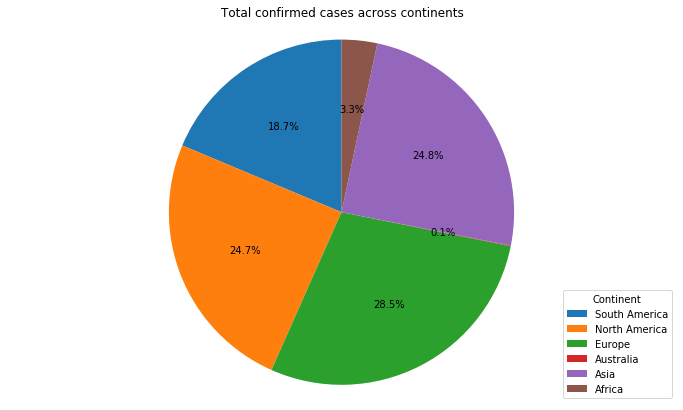

```python
f, ax = plt.subplots(figsize=(12,7))
plt.pie(continent_count['Total_confirmed'],  startangle=90, autopct='%1.1f%%')
plt.legend(continent_count['Continent_Name'], loc="lower right", title = 'Continent')
plt.axis('equal')
plt.title('Total confirmed cases across continents')
plt.show()
```

- Europe has the most number of confirmed cases with 28.5% of the total cases reported globally
- Australia looks to be the safest place currently with 0.1% of the total reported cases

## Sub-region wise distribution of cases

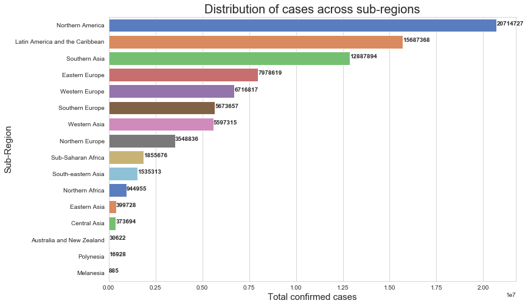

```python
sns.set_style("whitegrid")
bar,ax = plt.subplots(figsize=(12,8))
ax = sns.barplot(y='Sub-region Name', x='Total_confirmed', data=world_subregion_count, ci=None, palette="muted",orient='h' )
ax.set_title("Distribution of cases across sub-regions", fontsize=20)
ax.set_xlabel ("Total confirmed cases", fontsize=15)
ax.set_ylabel ("Sub-Region", fontsize=15)
for rect in ax.patches:
    ax.text (rect.get_width(), rect.get_y() + rect.get_height() / 2,"%.0f"% rect.get_width(), weight='bold' )
plt.show()
```

- North America has the maximum no. of reported cases followed by Latin America
- Regions in Australia have the least no. of reported cases with Melanesia reporting the least no. of cases

## Comparison of growth across countries based on the days since the first reported case

### Plot a multiseries line chart

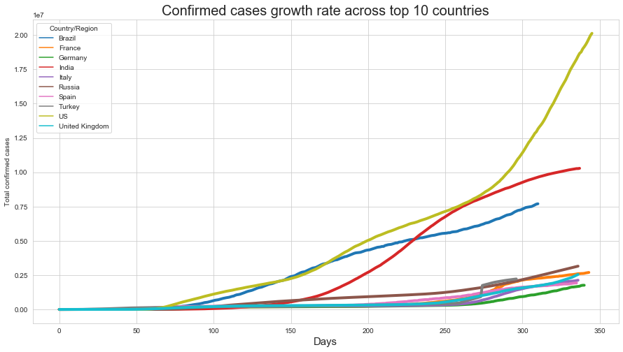

```python
#sns.lineplot(data=dayN_df.iloc[:, 1:11],dashes = False)
#sns.lineplot(x='Year', y='value', hue='variable', data=pd.melt(data_preproc, ['Year']))

sns.set_style("whitegrid")
bar,ax = plt.subplots(figsize=(15,8))
ax = sns.lineplot(data=dayN_df.iloc[:, 1:11],dashes = False, linewidth=4)
ax.set_title("Confirmed cases growth rate across top 10 countries", fontsize=20)
ax.set_xlabel ("Days", fontsize=15)
ax.set_ylabel ("Total confirmed cases")
plt.show()
```

- The top 10 countries with the maximum no. of cases are considered in this chart
- Chart shows the total no. of cases reported starting from the first day of reported cases in that country
- USA has the steepest growth rate & the maximum no. of cases reported followed by India

## Monthly cases reported in top10 countries - HeatMap

```python
# Add the month-year column and group the data for each month for the top 10 countries
confirmed_byDate['Date_month'] = confirmed_byDate['Date'].apply(lambda x: pd.to_datetime(pd.datetime.strptime(x, '%m/%d/%y').strftime('%B-%Y')))
monthlydf = confirmed_byDate.groupby('Date_month')[top10_byCountry].sum()
monthlydf.index = pd.to_datetime(monthlydf.index, format = '%Y-%m-%d').strftime('%B-%Y')
```

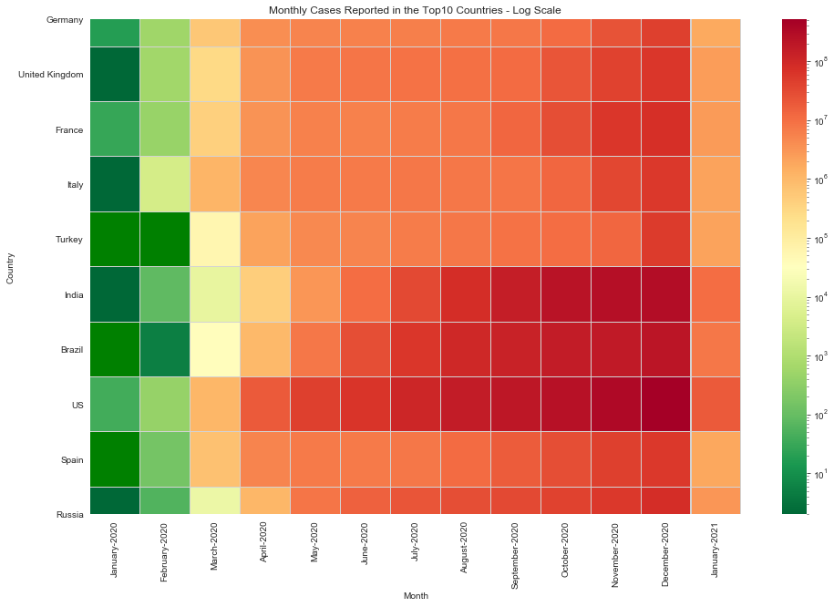

```python
# Heatmap is plotted on log scale so that the gradual change in the no. of cases is comparable
plt.figure(figsize=(16, 10))
my_cmap = copy.copy(cm.get_cmap('RdYlGn_r')) # copy the default cmap
my_cmap.set_bad(color='green')
sns.heatmap(monthlydf.T,cmap=my_cmap,  linewidth=0.05, linecolor='lightgrey', norm=LogNorm())

plt.xlabel('Month')
plt.ylabel('Country')
plt.title('Monthly Cases Reported in the Top10 Countries - Log Scale')
plt.show()
```

## World-wide growth of total cases

```python
# Multiseries line chart
world_CRD_byDate.head()
```

| Country/Region | Date | Total_confirmed | Daily_confirmed | Total_recovered | Daily_recovered | Total_death | Daily_death |
| --- | --- | --- | --- | --- | --- | --- | --- |
| 0 | 1/22/20 | 555.0 | NaN | 28.0 | NaN | 17.0 | NaN |
| 1 | 1/23/20 | 654.0 | 99.0 | 30.0 | 2.0 | 18.0 | 1.0 |
| 2 | 1/24/20 | 941.0 | 287.0 | 36.0 | 6.0 | 26.0 | 8.0 |
| 3 | 1/25/20 | 1434.0 | 493.0 | 39.0 | 3.0 | 42.0 | 16.0 |
| 4 | 1/26/20 | 2118.0 | 684.0 | 52.0 | 13.0 | 56.0 | 14.0 |

```python
#pd.to_datetime(world_CRD_byDate['Date'], format = '%Y-%m-%d')
```

```python
total_CRD_byDate = world_CRD_byDate.loc[:,['Date', 'Total_confirmed','Total_recovered','Total_death']]
total_CRD_byDate['Date'] = pd.to_datetime(total_CRD_byDate['Date'], format = '%m/%d/%y')
total_CRD_byDate.set_index('Date',inplace=True)
```

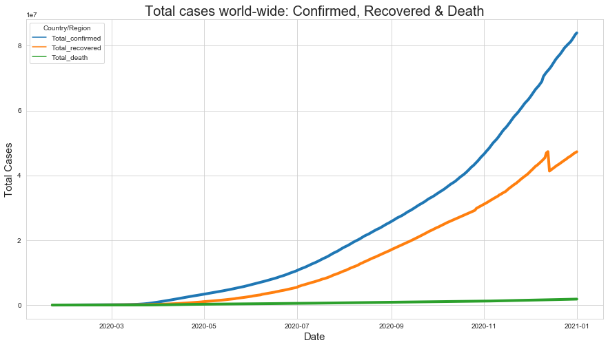

```python
sns.set_style("whitegrid")
bar,ax = plt.subplots(figsize=(15,8))
ax = sns.lineplot(data=total_CRD_byDate,dashes = False, linewidth=4)
ax.set_title("Total cases world-wide: Confirmed, Recovered & Death", fontsize=20)
ax.set_ylabel ("Total Cases", fontsize=15)
ax.set_xlabel ("Date", fontsize=15)
plt.show()
```

## World wide growth of daily confirmed cases

```python
world_CRD_byDate[world_CRD_byDate['Daily_recovered']<0]
```

| Country/Region | Date | Total_confirmed | Daily_confirmed | Total_recovered | Daily_recovered | Total_death | Daily_death |
| --- | --- | --- | --- | --- | --- | --- | --- |
| 327 | 12/14/20 | 72870103.0 | 524425.0 | 41327851.0 | -5992171.0 | 1621452.0 | 8965.0 |

```python
daily_CRD_byDate = world_CRD_byDate.loc[:,['Date', 'Daily_confirmed','Daily_recovered','Daily_death']]
# Remove any outliers in the data - happens during data correction
daily_CRD_byDate = daily_CRD_byDate[(daily_CRD_byDate['Daily_confirmed']>0) & (daily_CRD_byDate['Daily_recovered']>0) & (daily_CRD_byDate['Daily_death']>0) ]
daily_CRD_byDate['Date'] = pd.to_datetime(daily_CRD_byDate['Date'], format = '%m/%d/%y')
daily_CRD_byDate.set_index('Date',inplace=True)
```

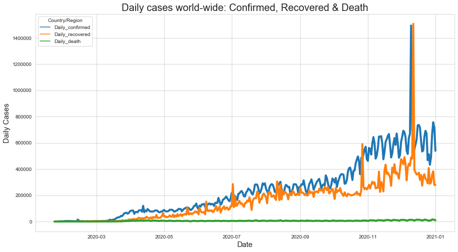

```python
sns.set_style("whitegrid")
bar,ax = plt.subplots(figsize=(15,8))
ax = sns.lineplot(data=daily_CRD_byDate,dashes = False, linewidth=4)
ax.set_title("Daily cases world-wide: Confirmed, Recovered & Death", fontsize=20)
ax.set_ylabel ("Daily Cases", fontsize=15)
ax.set_xlabel ("Date", fontsize=15)
plt.show()
```

## Last one week trend - CRD

### Extract last 7 days data and get the no. of confirmed, recovered and death cases for each day

```python
last7days = world_CRD_byDate.tail(7)[['Date','Daily_confirmed','Daily_recovered','Daily_death']]
last7days.rename(columns = {'Daily_confirmed':'Confirmed','Daily_recovered':'Recovered','Daily_death':'Death'}, inplace = True)
last7daysCRD = last7days.melt('Date', var_name='CRD', value_name='Total_cases')
```

### Plot a grouped bar chart

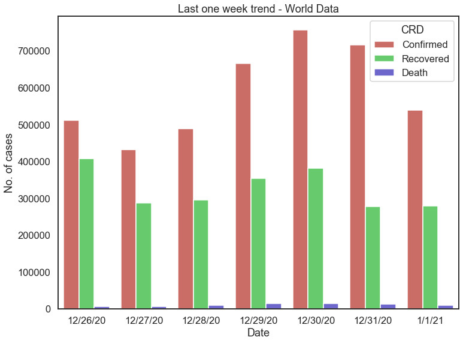

```python
sns.set(style="white", context="talk")
f, ax = plt.subplots(figsize=(12,9))
ax = sns.barplot(x=last7daysCRD['Date'],y=last7daysCRD['Total_cases'],hue=last7daysCRD['CRD'], palette = 'hls')
ax.set(xlabel='Date', ylabel='No. of cases')
plt.title("Last one week trend - World Data")
plt.show()
```

## Correlation between Confirmed, Recovered & Death cases

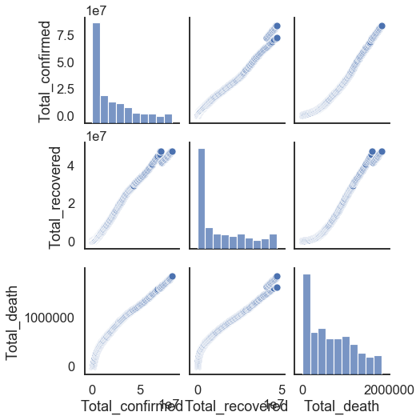

```python
sns.pairplot(world_CRD_byDate[['Total_confirmed','Total_recovered','Total_death']])
```

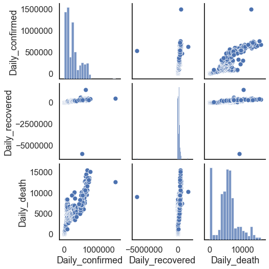

```python
sns.pairplot(world_CRD_byDate[['Daily_confirmed','Daily_recovered','Daily_death']])
```

# Seasonal - decomposition

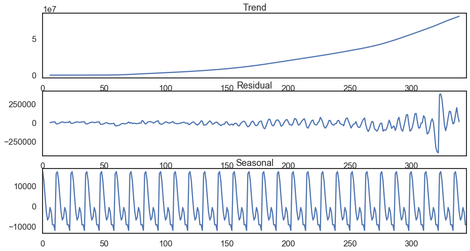

```python
from statsmodels.tsa.seasonal import seasonal_decompose
from matplotlib import pyplot
result = seasonal_decompose(world_CRD_byDate['Total_confirmed'], model='additive', freq=12)

fig, (ax1,ax2,ax3) = pyplot.subplots(3,1, figsize=(15,8))
result.trend.plot(ax=ax1)
result.resid.plot(ax=ax2)
result.seasonal.plot(ax=ax3)
ax1.title.set_text('Trend')
ax2.title.set_text('Residual')
ax3.title.set_text('Seasonal')
```